# 5100 Project Q1

Bilal Malik

2025-11-25

# How does public trust in government relate to public approval for spending on parks, bridges, and mass transportation?

## Libraries

```r
library(tidyverse)
library(car)
library(haven)
library(boot)
library(dplyr)
```

## Data Import

```r
gss <- read_sav("./data/GSS_spss/gss7224_r2.sav")

vars_needed <- c("conlegis", "confed", "conjudge",
                 "natpark", "natmass", "natroad",
                 "year")

gss_sub <- gss %>% select(all_of(vars_needed))
```

## Cleaning

```r
gss_clean <- gss_sub %>%
  mutate(
    conlegis = factor(conlegis, levels = c(1,2,3), ordered = TRUE),
    confed   = factor(confed,   levels = c(1,2,3), ordered = TRUE),
    conjudge = factor(conjudge, levels = c(1,2,3), ordered = TRUE),

    natpark  = factor(natpark,  levels = c(1,2,3), ordered = TRUE),
    natmass  = factor(natmass,  levels = c(1,2,3), ordered = TRUE),
    natroad  = factor(natroad,  levels = c(1,2,3), ordered = TRUE)
  )
```

## EDA

### Distribution of Government Trust Variables

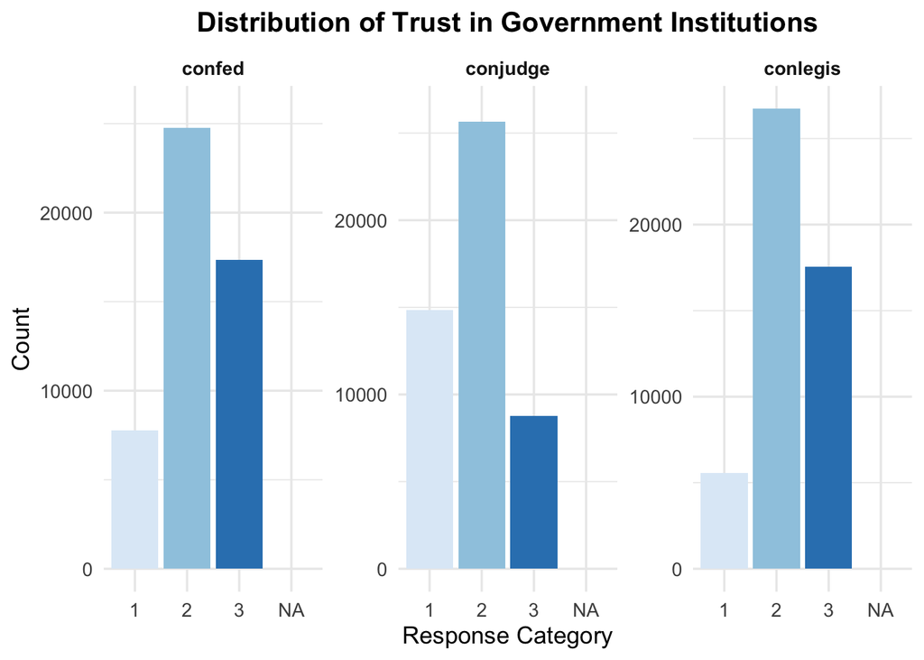

```r
gss_clean %>%
  select(conlegis, confed, conjudge) %>%
  pivot_longer(everything()) %>%
  ggplot(aes(x = value, fill = value)) +
  geom_bar(show.legend = FALSE) +
  facet_wrap(~ name, scales = "free_y") +
  scale_fill_brewer(palette = "Blues") +
  labs(
    title = "Distribution of Trust in Government Institutions",
    x = "Response Category",
    y = "Count"
  ) +
  theme_minimal(base_size = 13) +
  theme(
    strip.text = element_text(face = "bold"),
    plot.title = element_text(face = "bold", size = 15, hjust = 0.5)
  )
```

### Distribution of Public Spending Pref

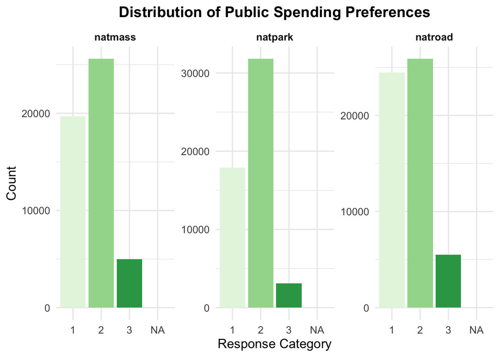

```r
gss_clean %>%
  select(natpark, natmass, natroad) %>%
  pivot_longer(everything()) %>%
  ggplot(aes(x = value, fill = value)) +
  geom_bar(show.legend = FALSE) +
  facet_wrap(~ name, scales = "free_y") +
  scale_fill_brewer(palette = "Greens") +
  labs(
    title = "Distribution of Public Spending Preferences",
    x = "Response Category",
    y = "Count"
  ) +
  theme_minimal(base_size = 13) +
  theme(
    strip.text = element_text(face = "bold"),
    plot.title = element_text(face = "bold", size = 15, hjust = 0.5)
  )
```

The visualization for spending preferences reveals that the most common response for parks (`natpark`) and mass transportation (`natmass`) is **“ABOUT RIGHT” (Category 2)**. This indicates that the majority of the public is satisfied with current spending levels for these two areas. For roads/bridges (`natroad`), “ABOUT RIGHT” (Category 2) is nearly tied with **“TOO LITTLE” (Category 1)**, suggesting a significant portion of the public favors **increased spending** on infrastructure. **“TOO MUCH” (Category 3)** is consistently the least frequent response across all three categories. This establishes the **dependent variable** context for Objective 1, showing that while most people are satisfied or want more spending, there are important variations by public good which can now be correlated with public trust in government.

### Yearly Trends

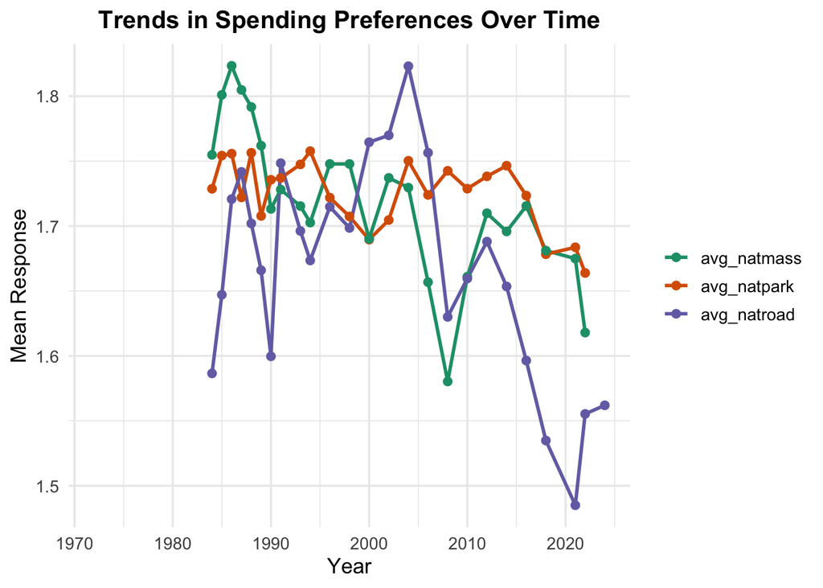

```r
gss_clean %>%
  group_by(year) %>%
  summarize(
    avg_natpark = mean(as.numeric(natpark), na.rm = TRUE),
    avg_natmass = mean(as.numeric(natmass), na.rm = TRUE),
    avg_natroad = mean(as.numeric(natroad), na.rm = TRUE)
  ) %>%
  pivot_longer(-year, names_to = "variable", values_to = "value") %>%
  ggplot(aes(x = year, y = value, color = variable)) +
  geom_line(linewidth = 1) +
  geom_point(size = 2) +
  scale_color_brewer(palette = "Dark2") +
  labs(
    title = "Trends in Spending Preferences Over Time",
    x = "Year",
    y = "Mean Response"
  ) +
  theme_minimal(base_size = 13) +
  theme(
    legend.title = element_blank(),
    plot.title = element_text(face = "bold", size = 15, hjust = 0.5)
  )
```

## Hypothesis Testing

```r
gss_clean <- gss_sub %>%
  mutate(
    conlegis = na_if(conlegis, 0),
    confed   = na_if(confed, 0),
    conjudge = na_if(conjudge, 0),
    natpark  = na_if(natpark, 0),
    natmass  = na_if(natmass, 0),
    natroad  = na_if(natroad, 0)
  ) %>%
  filter(
    conlegis %in% c(1,2,3),
    confed   %in% c(1,2,3),
    conjudge %in% c(1,2,3),
    natpark  %in% c(1,2,3),
    natmass  %in% c(1,2,3),
    natroad  %in% c(1,2,3)
  ) %>%
  mutate(
    conlegis = factor(conlegis, levels = c(1,2,3),
                      labels = c("High trust", "Medium trust", "Low trust")),
    confed   = factor(confed,   levels = c(1,2,3),
                      labels = c("High trust", "Medium trust", "Low trust")),
    conjudge = factor(conjudge, levels = c(1,2,3),
                      labels = c("High trust", "Medium trust", "Low trust")),

    natpark  = factor(natpark,  levels = c(1,2,3),
                      labels = c("Increase spending", "Keep same", "Decrease spending")),
    natmass  = factor(natmass,  levels = c(1,2,3),
                      labels = c("Increase spending", "Keep same", "Decrease spending")),
    natroad  = factor(natroad,  levels = c(1,2,3),
                      labels = c("Increase spending", "Keep same", "Decrease spending"))
  )
```

```r
# Chi-square: Congress trust × park spending
chisq_conlegis_natpark <- chisq.test(table(gss_clean$conlegis, gss_clean$natpark))
chisq_conlegis_natpark
```

```
##
##  Pearson's Chi-squared test
##
## data:  table(gss_clean$conlegis, gss_clean$natpark)
## X-squared = 105.02, df = 4, p-value < 2.2e-16
```

```r
# Chi-square: Court trust × mass transit
chisq_conjudge_natmass <- chisq.test(table(gss_clean$conjudge, gss_clean$natmass))
chisq_conjudge_natmass
```

```
##
##  Pearson's Chi-squared test
##
## data:  table(gss_clean$conjudge, gss_clean$natmass)
## X-squared = 127.33, df = 4, p-value < 2.2e-16
```

```r
# Chi-square: Federal trust × road/bridge spending
chisq_confed_natroad <- chisq.test(table(gss_clean$confed, gss_clean$natroad))
chisq_confed_natroad
```

```
##
##  Pearson's Chi-squared test
##
## data:  table(gss_clean$confed, gss_clean$natroad)
## X-squared = 232.36, df = 4, p-value < 2.2e-16
```

```r
# Expected counts
chisq_conlegis_natpark$expected
```

```
##
##                Increase spending Keep same Decrease spending
##   High trust            1016.316  1789.969          169.7154
##   Medium trust          5244.817  9237.346          875.8365
##   Low trust             4020.867  7081.685          671.4481
```

```r
chisq_conjudge_natmass$expected
```

```
##
##                Increase spending Keep same Decrease spending
##   High trust            3599.851  4655.958          926.1902
##   Medium trust          6176.047  7987.945         1589.0083
##   Low trust             2028.102  2623.097          521.8015
```

```r
chisq_confed_natroad$expected
```

```
##
##                Increase spending Keep same Decrease spending
##   High trust            1985.361  2096.683          428.9555
##   Medium trust          6369.353  6726.490         1376.1570
##   Low trust             4896.286  5170.827         1057.8874
```

All three tests produced extremely small p-values (<2.2e−16), which is far less than the conventional α=0.05 threshold. We **reject the null hypothesis** (that trust and spending approval are independent).  
1. Congress Trust (conlegis) vs. Park Spending (natpark): χ2=105.02,df=4,p<2.2e−16.  
2. Court Trust (conjudge) vs. Mass Transit (natmass): χ2=127.33,df=4,p<2.2e−16.  
3. Federal Trust (confed) vs. Road Spending (natroad): χ2=232.36,df=4,p<2.2e−16.

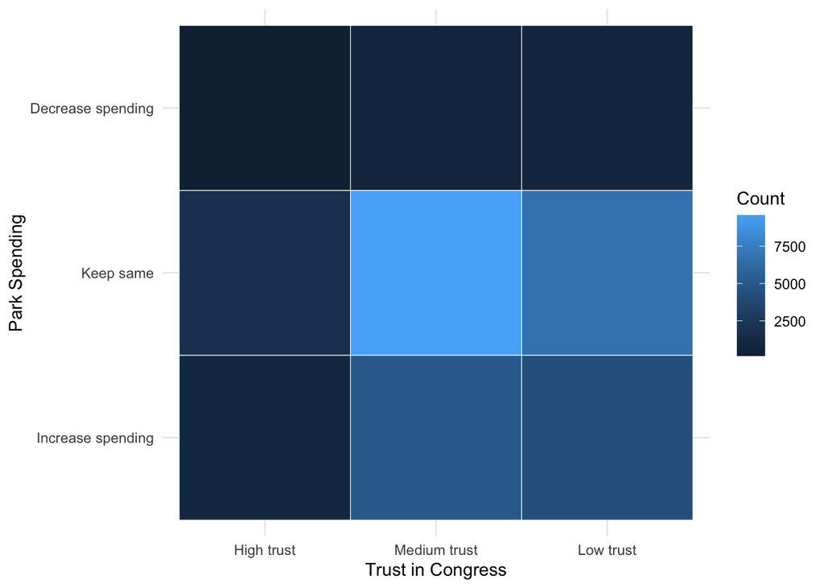

```r
tab <- table(gss_clean$conlegis, gss_clean$natpark)
df <- as.data.frame(tab)

ggplot(df, aes(Var1, Var2, fill = Freq)) +
  geom_tile(color = "white") +
  scale_fill_gradient() +
  labs(x = "Trust in Congress", y = "Park Spending", fill = "Count") +
  theme_minimal()
```

The data demonstrates a **highly significant relationship** between the **public’s trust in government** and **their approval of spending on public goods**. Specifically, the most common public sentiment is characterized by moderate trust in government coupled with a preference to **maintain current spending levels**. However, the crosstabulation suggests that those with **Medium or Low trust** are more numerous and **more inclined to favor increased spending** on these public goods compared to those with High trust, indicating that dissatisfaction with government may not translate into a desire to cut public services.

## Kruskal-Wallis

```r
gss_clean <- gss_clean %>%
  mutate(
    natpark_num = as.numeric(natpark),
    natmass_num = as.numeric(natmass),
    natroad_num = as.numeric(natroad)
  )

# Check Homogeneity of Variance
levene_park <- leveneTest(natpark_num ~ conlegis, data = gss_clean)
levene_mass <- leveneTest(natmass_num ~ conjudge, data = gss_clean)
levene_road <- leveneTest(natroad_num ~ confed, data = gss_clean)

levene_park
```

```
## Levene's Test for Homogeneity of Variance (center = median)
##          Df F value    Pr(>F)
## group     2  38.123 < 2.2e-16 ***
##       30105
## ---
## Signif. codes:  0 '***' 0.001 '**' 0.01 '*' 0.05 '.' 0.1 ' ' 1
```

```r
levene_mass
```

```
## Levene's Test for Homogeneity of Variance (center = median)
##          Df F value    Pr(>F)
## group     2  39.423 < 2.2e-16 ***
##       30105
## ---
## Signif. codes:  0 '***' 0.001 '**' 0.01 '*' 0.05 '.' 0.1 ' ' 1
```

```r
levene_road
```

```
## Levene's Test for Homogeneity of Variance (center = median)
##          Df F value    Pr(>F)
## group     2  113.89 < 2.2e-16 ***
##       30105
## ---
## Signif. codes:  0 '***' 0.001 '**' 0.01 '*' 0.05 '.' 0.1 ' ' 1
```

The **Levene’s Tests** for all three spending/trust pairs (Parks/Congress, Mass Transit/Courts, Roads/Federal) yielded highly significant p-values (p<2.2e−16). This result confirms that the assumption of **homogeneity of variances is violated** for all comparisons. This justifies the use of the non-parametric **Kruskal-Wallis test** instead of a traditional ANOVA.

```r
# Kruskal-Wallis Tests
kruskal_park  <- kruskal.test(natpark_num ~ conlegis, data = gss_clean)
kruskal_mass  <- kruskal.test(natmass_num ~ conjudge, data = gss_clean)
kruskal_road  <- kruskal.test(natroad_num ~ confed, data = gss_clean)

kruskal_park
```

```
##
##  Kruskal-Wallis rank sum test
##
## data:  natpark_num by conlegis
## Kruskal-Wallis chi-squared = 5.5055, df = 2, p-value = 0.06375
```

```r
kruskal_mass
```

```
##
##  Kruskal-Wallis rank sum test
##
## data:  natmass_num by conjudge
## Kruskal-Wallis chi-squared = 2.1124, df = 2, p-value = 0.3478
```

```r
kruskal_road
```

```
##
##  Kruskal-Wallis rank sum test
##
## data:  natroad_num by confed
## Kruskal-Wallis chi-squared = 57.418, df = 2, p-value = 3.403e-13
```

The Kruskal-Wallis tests assessed whether the median spending preference differed significantly across the three trust groups (Low, Medium, High).  
**1. Roads/Federal Trust (**natroad vs. confed): This relationship is **highly significant** (χ2=57.418,df=2,p=3.403e−13). We reject the null hypothesis, concluding that at least one trust group’s median preference for road spending differs significantly from the others.  
**2. Parks/Congress Trust (**natpark vs. conlegis): The result is **marginally non-significant** (χ2=5.5055,df=2,p=0.06375). While close to the α=0.05 cutoff, we fail to reject the null hypothesis, suggesting that differences in the median rank are not statistically robust.  
**3. Mass Transit/Court Trust (**natmass vs. conjudge): The result is **not significant** (χ2=2.1124,df=2,p=0.3478). We fail to reject the null hypothesis.

```r
# Post-Hoc Pairwise Comparisons
posthoc_road <- pairwise.wilcox.test(
  gss_clean$natroad_num,
  gss_clean$confed,
  p.adjust.method = "bonferroni"
)

posthoc_road
```

```
##
##  Pairwise comparisons using Wilcoxon rank sum test with continuity correction
##
## data:  gss_clean$natroad_num and gss_clean$confed
##
##              High trust Medium trust
## Medium trust 1          -
## Low trust    8.5e-08    1.2e-11
##
## P value adjustment method: bonferroni
```

The key finding is that the **Low trust** group’s median road spending preference is **significantly different** from both the **High trust** and **Medium trust** groups. The High and Medium trust groups, however, do not significantly differ from each other.

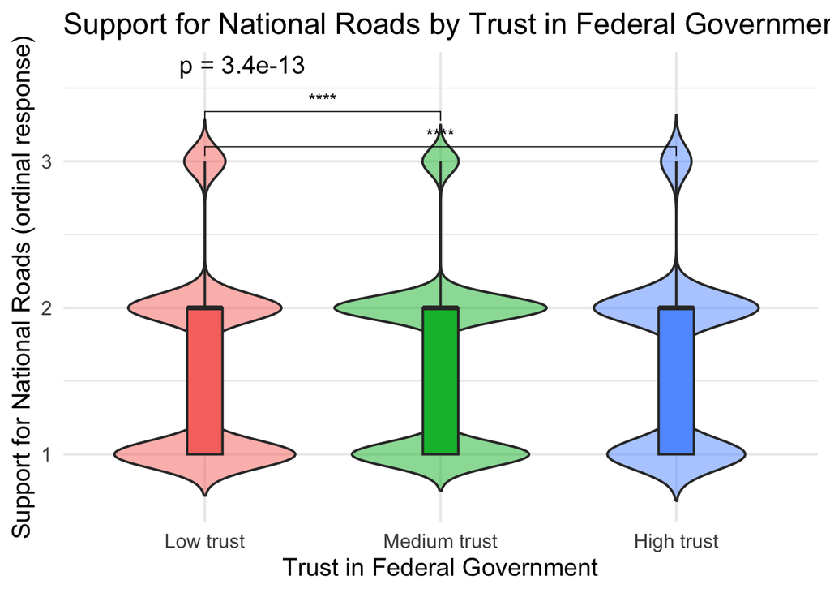

```r
library(ggplot2)
library(ggpubr)

# Ensure factor ordering
gss_clean$confed <- factor(
  gss_clean$confed,
  levels = c("Low trust", "Medium trust", "High trust")
)

# Comparisons for post-hoc
my_comparisons <- list(
  c("High trust", "Low trust"),
  c("Medium trust", "Low trust")
)

ggplot(gss_clean, aes(x = confed, y = natroad_num, fill = confed)) +
  geom_violin(trim = FALSE, alpha = 0.5) +
  geom_boxplot(width = 0.15, outlier.size = 0.8) +

  # Kruskal-Wallis label
  stat_compare_means(
    method = "kruskal.test",
    label = "p.format",
    label.y = 3.6   # move above violins
  ) +

  # Pairwise Wilcoxon
  stat_compare_means(
    comparisons = my_comparisons,
    method = "wilcox.test",
    p.adjust.method = "bonferroni",
    label = "p.signif",   # guaranteed allowed
    hide.ns = TRUE
  ) +

  labs(
    title = "Support for National Roads by Trust in Federal Government",
    x = "Trust in Federal Government",
    y = "Support for National Roads (ordinal response)"
  ) +
  theme_minimal(base_size = 15) +
  theme(legend.position = "none")
```

## Bootstrap

```r
set.seed(123)

gss_boot <- gss_clean %>%
  mutate(
    park_increase = ifelse(natpark == "Increase spending", 1, 0),
    mass_increase = ifelse(natmass == "Increase spending", 1, 0),
    road_increase = ifelse(natroad == "Increase spending", 1, 0),

    conlegis = factor(conlegis, levels = c("Low trust", "High trust")),
    conjudge = factor(conjudge, levels = c("Low trust", "High trust")),
    confed   = factor(confed,   levels = c("Low trust", "High trust"))
  )

gss_park <- gss_boot %>% filter(conlegis %in% c("High trust", "Low trust"))
gss_mass <- gss_boot %>% filter(conjudge %in% c("High trust", "Low trust"))
gss_road <- gss_boot %>% filter(confed %in% c("High trust", "Low trust"))

diff_prop <- function(data, indices, outcome_var, group_var) {
  d <- data[indices, ]
  prop_high <- mean(d[[outcome_var]][d[[group_var]] == "High trust"])
  prop_low  <- mean(d[[outcome_var]][d[[group_var]] == "Low trust"])
  return(prop_high - prop_low)
}
```

```r
boot_park <- boot(data = gss_park,
                  statistic = function(d, i) diff_prop(d, i, "park_increase", "conlegis"),
                  R = 5000)

boot_mass <- boot(data = gss_mass,
                  statistic = function(d, i) diff_prop(d, i, "mass_increase", "conjudge"),
                  R = 5000)

boot_road <- boot(data = gss_road,
                  statistic = function(d, i) diff_prop(d, i, "road_increase", "confed"),
                  R = 5000)
```

```r
boot.ci(boot_park, type = c("perc", "bca"))
```

```
## BOOTSTRAP CONFIDENCE INTERVAL CALCULATIONS
## Based on 5000 bootstrap replicates
##
## CALL :
## boot.ci(boot.out = boot_park, type = c("perc", "bca"))
##
## Intervals :
## Level     Percentile            BCa
## 95%   (-0.0391, -0.0002 )   (-0.0398, -0.0006 )
## Calculations and Intervals on Original Scale
```

```r
boot.ci(boot_mass, type = c("perc", "bca"))
```

```
## BOOTSTRAP CONFIDENCE INTERVAL CALCULATIONS
## Based on 5000 bootstrap replicates
##
## CALL :
## boot.ci(boot.out = boot_mass, type = c("perc", "bca"))
##
## Intervals :
## Level     Percentile            BCa
## 95%   (-0.0382, -0.0050 )   (-0.0379, -0.0048 )
## Calculations and Intervals on Original Scale
```

```r
boot.ci(boot_road, type = c("perc", "bca"))
```

```
## BOOTSTRAP CONFIDENCE INTERVAL CALCULATIONS
## Based on 5000 bootstrap replicates
##
## CALL :
## boot.ci(boot.out = boot_road, type = c("perc", "bca"))
##
## Intervals :
## Level     Percentile            BCa
## 95%   (-0.0851, -0.0506 )   (-0.0850, -0.0505 )
## Calculations and Intervals on Original Scale
```

The bootstrap analysis provides 95% confidence intervals for the true difference in the proportion of people who want to **“Increase spending”** between the **High trust** group and the **Low trust** group. Since all three confidence intervals **do not contain zero**, we conclude there is a statistically significant difference in the desire for increased spending between the High trust and Low trust groups for all three public goods. Because all confidence intervals are entirely negative, the true difference (PropHigh − PropLow) is less than zero. This means that; **PropHigh < PropLow**. Therefore, the **Low trust group** has a **higher proportion** of respondents who want to **increase spending** compared to the High trust group.

```r
boot_df <- data.frame(
  park  = boot_park$t,
  mass  = boot_mass$t,
  road  = boot_road$t
) %>%
  pivot_longer(cols = everything(), names_to = "type", values_to = "diff_prop")
```

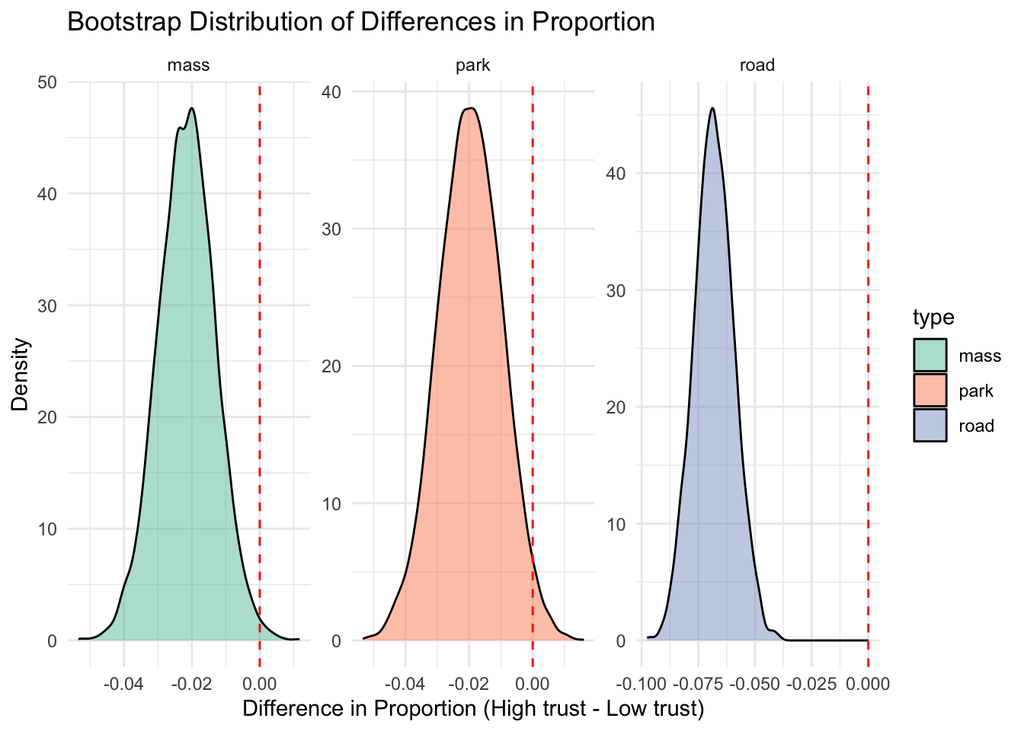

```r
ggplot(boot_df, aes(x = diff_prop, fill = type)) +
  geom_density(alpha = 0.5) +
  facet_wrap(~ type, scales = "free") +
  geom_vline(xintercept = 0, linetype = "dashed", color = "red") +
  labs(
    title = "Bootstrap Distribution of Differences in Proportion",
    x = "Difference in Proportion (High trust - Low trust)",
    y = "Density"
  ) +
  theme_minimal() +
  scale_fill_brewer(palette = "Set2")
```

## Results

**The relationship between public trust in government and approval for spending on public goods is statistically significant and negative.**

For all three types of spending (parks, mass transit, and roads/bridges), the analysis consistently shows that **respondents with Low trust in government are significantly more likely to favor increased spending** than those with High trust. The largest difference is seen in **Roads/Bridges**, where the proportion of those wanting increased spending is approximately **5% to 8.5% higher** in the Low trust group compared to the High trust group. This strongly suggests that a lack of trust in the institutions managing the funds does not lead the public to demand cuts in public services; instead, the group most distrustful of government is simultaneously the group most demanding of infrastructure and public goods investment.